# The Singular Value Decomposition

One Idea Behind Data, Images, and Linear Algebra

Ivan Ricardo

iu.ricardo@maastrichtuniversity.nl

Maastricht University

January 31, 2026

## Motivation

- How does your phone compress photos?
- Why does Google Photos recognize faces?
- How can we simplify messy data without losing too much information?

[figure not shown]

## Matrices as Images

- Images can be represented by matrices, or tables, with certain numbers of rows and columns
- Typically, we have color (Red Green Blue, or RGB) images, which can be represented by three matrices
- However, we can make things simple and start with one gray matrix
- We will then turn the gray matrix into numbers so it is easier to perform math on this

## Gray Matrix Representation

```julia
using Images, LinearAlgebra
img = load("img/porco.jpg")
gray_img = Gray.(img)
```

[figure not shown]

## Numbers Behind the Pixels

- Each cell is a number from 0.0 to 1.0
- 0.0 is black and 1.0 is white

```julia
gray_matrix = Float64.(gray_img)
```

```
921×1620 Matrix{Float64}:
 0.498039  0.509804  0.517647  0.521569  …  0.568627  0.568627  0.568627
 0.670588  0.678431  0.686275  0.686275     0.733333  0.733333  0.733333
 0.682353  0.690196  0.694118  0.690196     0.756863  0.756863  0.756863
 0.670588  0.67451   0.678431  0.67451      0.745098  0.745098  0.745098
 0.690196  0.694118  0.694118  0.690196     0.745098  0.745098  0.745098
 0.67451   0.67451   0.67451   0.670588  …  0.733333  0.733333  0.733333
 0.678431  0.682353  0.682353  0.67451      0.752941  0.752941  0.752941
 0.666667  0.670588  0.670588  0.666667     0.733333  0.733333  0.733333
 0.686275  0.682353  0.678431  0.67451      0.745098  0.745098  0.745098
 0.686275  0.682353  0.678431  0.67451      0.745098  0.745098  0.745098
 0.686275  0.682353  0.678431  0.67451   …  0.74902   0.74902   0.74902
 0.686275  0.682353  0.678431  0.67451      0.752941  0.752941  0.752941
 0.686275  0.682353  0.678431  0.67451      0.752941  0.752941  0.752941
 ⋮                                       ⋱
 0.611765  0.607843  0.603922  0.6          0.737255  0.745098  0.752941
 0.596078  0.596078  0.596078  0.596078  …  0.741176  0.74902   0.756863
 0.584314  0.584314  0.588235  0.592157     0.717647  0.72549   0.737255
 0.592157  0.596078  0.6       0.603922     0.721569  0.72549   0.729412
 0.592157  0.596078  0.6       0.6          0.717647  0.721569  0.72549
 0.592157  0.592157  0.596078  0.6          0.72549   0.72549   0.729412
 0.588235  0.592157  0.596078  0.6       …  0.729412  0.733333  0.737255
 0.588235  0.592157  0.596078  0.596078     0.721569  0.72549   0.729412
 0.588235  0.588235  0.592157  0.596078     0.705882  0.709804  0.713725
 0.584314  0.588235  0.592157  0.596078     0.701961  0.705882  0.709804
 0.584314  0.588235  0.592157  0.596078     0.713725  0.717647  0.721569
 0.45098   0.45098   0.45098   0.45098   …  0.52549   0.533333  0.556863
```

# The Singular Value Decomposition

## Breaking a Matrix Apart

- Call my matrix $\mathbf{A} \in \mathbb{R}^{m \times n}$
- We can decompose this matrix into the product of **three matrices**
  $$\mathbf{A} = \mathbf{U} \boldsymbol{\Sigma} \mathbf{V}^\top$$
- $\mathbf{U}$ are the “row-shapes” that show how each component spreads down the image (vertical patterns)
- $\boldsymbol{\Sigma}$ is a diagonal matrix that ranks the “importance” of components - bigger values means more important; small ones can be dropped
- $\mathbf{V}$ are the “column-shapes” that show how each component spreads across the image (horizontal patterns).

## Basic Properties

- The SVD exists for **all** real matrices (square or rectangular)
- The pieces have a fixed role:
  - $\mathbf{U}$ and $\mathbf{V}$ are *orthonormal* matrices ($\mathbf{U}^\top \mathbf{U} = \mathbf{I}_m$ and $\mathbf{V}^\top \mathbf{V} = \mathbf{I}_n$)
  - $\boldsymbol{\Sigma}$ is a (ordered) diagonal with non-negative numbers (singular values)

Singular values are ordered from greatest to least – they measure the **importance** of the patterns in the data or image.

## Eckart-Young-Mirsky Theorem

**Eckart-Young-Mirsky Theorem**

Let $\mathbf{A} \in \mathbb{R}^{m \times n}$ have SVD $\mathbf{A} = \mathbf{U} \boldsymbol{\Sigma} \mathbf{V}^\top$ and define $\mathbf{A}_k = \sum_{i=1}^k \boldsymbol{\sigma}_i \mathbf{u}_i \mathbf{v}_i$. $\mathbf{A}_k$ solves the optimization problem
$$\min_{\text{B of rank k}} \| \mathbf{A} - \mathbf{B} \|_*$$
for $* = \{2, F\}$. Furthermore,
$$\| \mathbf{A} - \mathbf{A}_k \|_2 = \boldsymbol{\sigma}_{k+1}, \quad \| \mathbf{A} - \mathbf{A}_k \|_F = \left(\sum_{i=k+1}^{\min(m, n)} \boldsymbol{\sigma}_i\right).$$

where
$$\| \mathbf{X} \|_2 = \boldsymbol{\sigma}_{\text{max}} \quad \text{and} \quad \| \mathbf{X} \|_F = \sqrt{\sum_{i, j}^{mn} x_{i,j}}.$$

## Eckart-Young-Mirsky Theorem

- Singular values measure how much each rank-one component contributes.
- Keep the biggest $k$ components and you lose exactly the next singular value in spectral norm and the squared sum of the remaining singular values in Frobenius norm,
  $$\| \mathbf{A} - \mathbf{A}_k \|_2 = \boldsymbol{\sigma}_{k+1}, \quad \| \mathbf{A} - \mathbf{A}_k \|_F = \left(\sum_{i=k+1}^{\min(m, n)} \boldsymbol{\sigma}_i\right).$$

# Application to Compression

## Application to Compression

[figure not shown]

- This image can be represented by a matrix $\mathbf{A} \in \mathbb{R}^{921 \times 1620}$.
- The SVD gives us $\mathbf{A} = \mathbf{U} \boldsymbol{\Sigma} \mathbf{V}^\top$ where
  - $\mathbf{U} \in \mathbb{R}^{921 \times 921}$
  - $\boldsymbol{\Sigma} \in \mathbb{R}^{921 \times 1620}$
  - $\mathbf{V} \in \mathbb{R}^{1620 \times 1620}$

## Singular Values in a Rectangular Matrix

- $\boldsymbol{\Sigma}$ is rectangular, so we have $\min(921, 1620) = 921$ singular values.
- What happens if we simply take the largest $k = 920$ singular values? In other words, we only “compress” the image by removing the last singular value and vector?
- This is a reduction in the rank of the original image by one, we should expect minimal noise reduction.

## k = 921

[figure not shown]

## k = 920

[figure not shown]

## k = 919

[figure not shown]

## k = 918

[figure not shown]

## k = 500

[figure not shown]

## k = 100

[figure not shown]

## k = 50

[figure not shown]

## k = 25

[figure not shown]

## k = 2

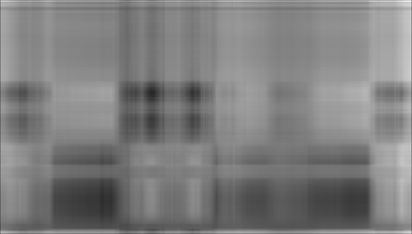

## But how does this compress?

- Instead of storing $m \times n$ numbers, we store $m \times k + n \times k + k$ numbers
- In our example, we have $921 \times 1620 = 1492020$ numbers to store.
- If we were to use $k = 100$, we store $921 \times 100 + 1620 \times 100 + 100 = 254200$ numbers
- This is approximately $17$% the size of the original image!
- But how do we determine the optimal number of $k$ in practice?

## Selecting k

- We may use a *scree plot*, which shows us how much information we lose at each $k$.

[figure not shown]

## Cumulative Energy / Variance Explained

- Alternatively, we may have a Cumulative Energy based estimator to estimate the number $k$ in practice
- Allows us to obtain a specific value $k$ without relying on our judgement
  $$k^* = \min \left( k: \frac{\sum_{i=1}^k \boldsymbol{\sigma}_i^2}{\sum_{i=1}^{\min(m, n)} \boldsymbol{\sigma}_i^2} \geq \tau\right)$$
- Keep enough singular values to capture a fixed fraction of total variance or “energy”

## Cumulative Energy / Variance Explained

```julia
S = svd_porco.S
τ = 0.999
cumulative_energy = cumsum(S.^2) ./ sum(S.^2)
k_star = findfirst(x -> x >= τ, cumulative_energy)
```

```
68
```

- In keeping $99.9$% of the variance, I want to have $k = 68$.
- This reduced the image storage from $1492020$ numbers to store to $172856$ numbers to store.
- The new image is approximately $11$% the size of the original image

## Image with k = 68

[figure not shown]

# Conclusion

## Conclusion

- SVD expresses an image as orthonormal matrices weighted by singular values – most visual information is concentrated in the first few components
- Eckart-Young-Mirsky guarantees the truncated SVD is the optimal rank-$k$ approximation (error controlled exactly by the discarded singular values in spectral/Frobenius norms).
- Practical rule: pick $k$ from a scree or cumulative-energy cutoff; e.g., $99.9$% energy at $k=68$ reduced storage to $\approx 11$% with minimal visual loss.